# Tarea 3

Rolando Fortanell

2025-02-06

# Ford

## Hecho Estilizado 1

```r
library(quantmod)
datos_ford <- new.env()
ford <- "F"
getSymbols(ford, env=datos_ford)
```

```
## [1] "F"
```

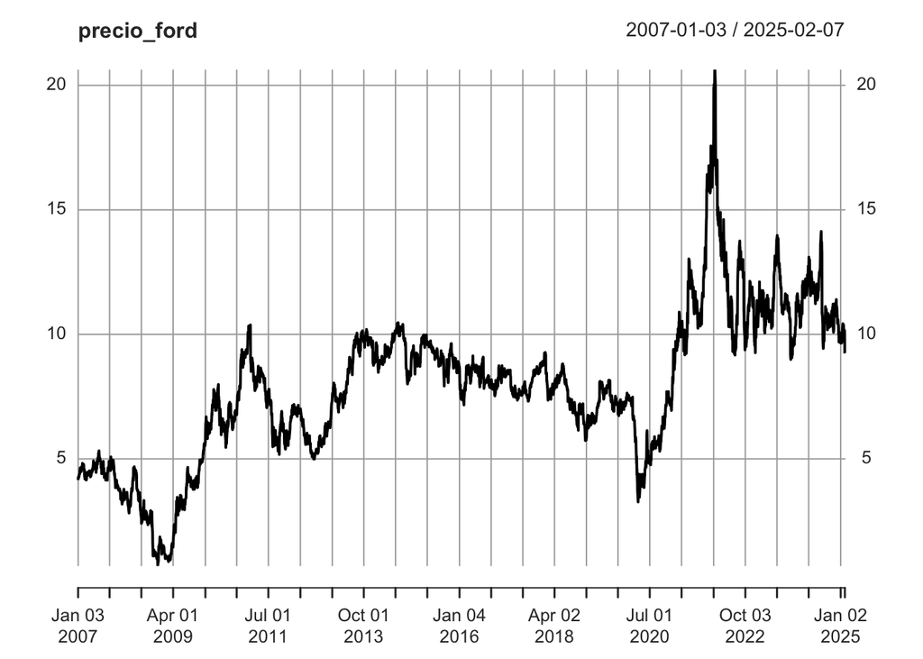

```r
precio_ford <- datos_ford[[ford]][,6]

plot(precio_ford)
```

Como podemos ver el precio de la acción de Ford tiene el comportamiento de una caminata aleatoria ya que no hay una tendencia establecida a traves del tiempo. Podemos observar que a largo plazo el precio de Ford tiene bastantes subidas y bajadas, unas más drásticas que las otras.

## Hecho Estilizado 2

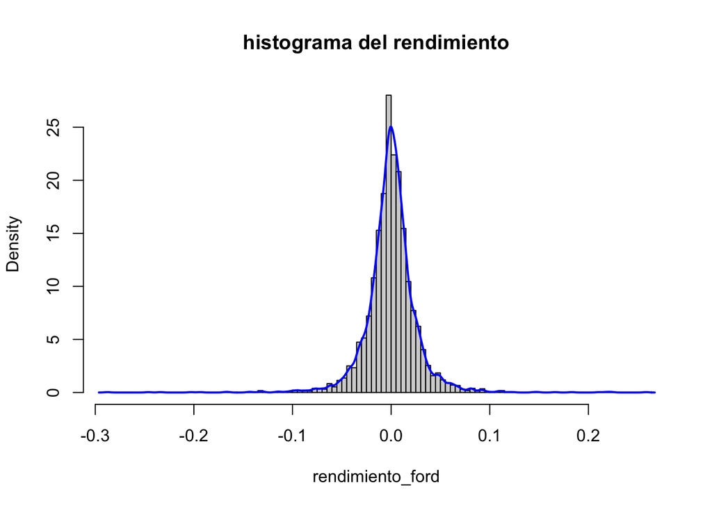

```r
rendimiento_ford <- na.omit(diff(log(precio_ford)))
hist(rendimiento_ford, n = 100,main="histograma del rendimiento", prob = TRUE)
lines(density(rendimiento_ford), col="blue", lwd=2)
```

```r
xval <- seq(min(rendimiento_ford),max(rendimiento_ford), length.out=100)
```

Podemos observar que la distribución del rendimiento del precio de Ford tiene una forma acampanada y que la media del rendimiento se agrupa alrededor de cero.

## Hecho Estilizado 3

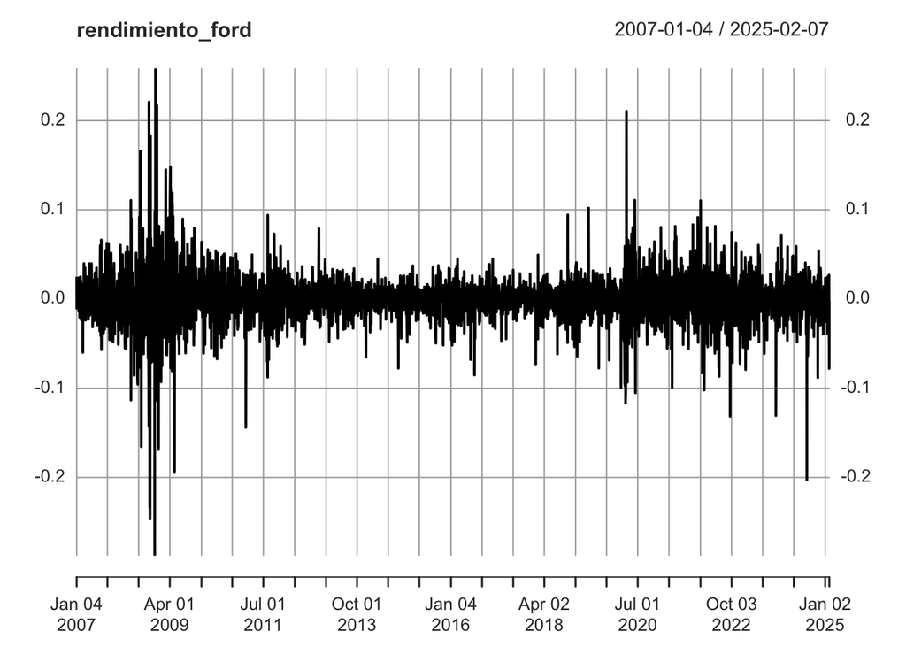

```r
plot(rendimiento_ford)
```

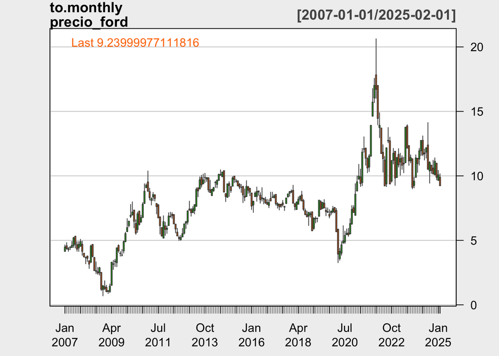

```r
chartSeries(to.monthly(precio_ford), theme="white")
```

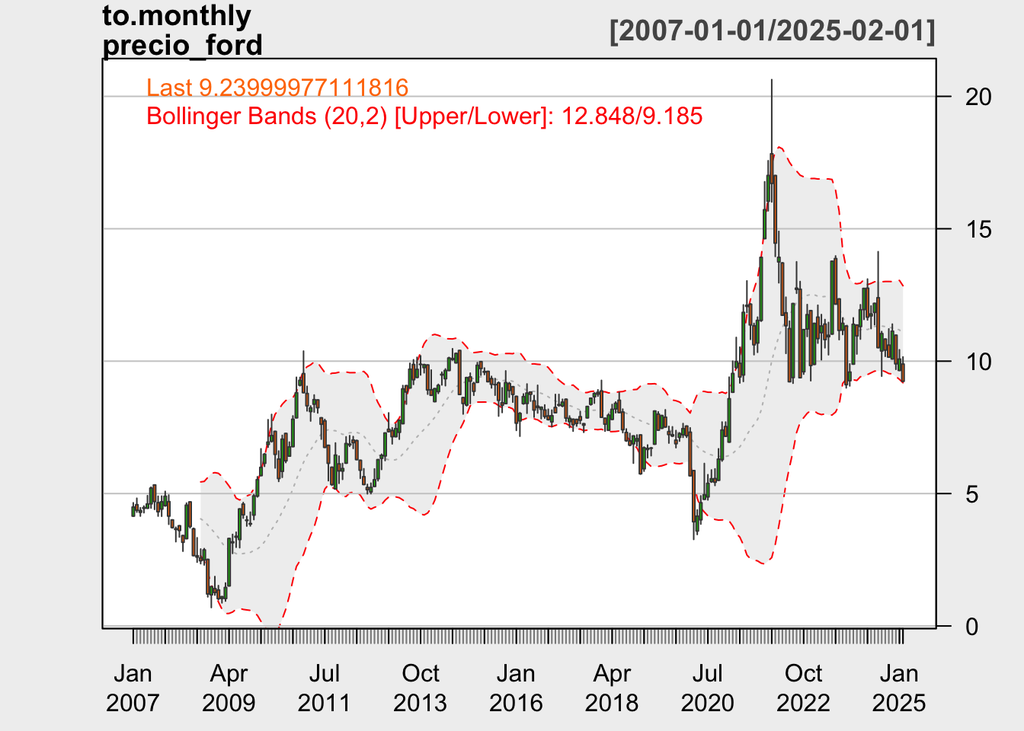

```r
addBBands()
```

Como podemos ver los rendimientos de ford presentan una volatilidad no constante y agrupada.

## Hecho Estillizado 4

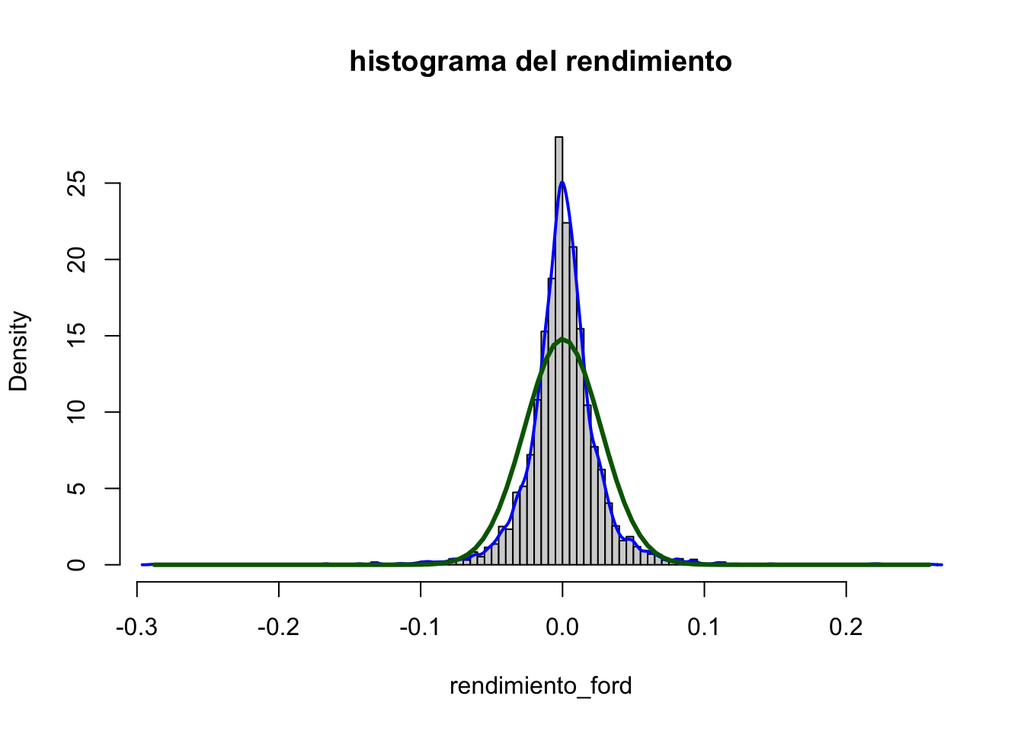

```r
rendimiento_ford <- na.omit(diff(log(precio_ford)))
hist(rendimiento_ford, n = 100,main="histograma del rendimiento", prob = TRUE)
lines(density(rendimiento_ford), col="blue", lwd=2)
xval <- seq(min(rendimiento_ford),max(rendimiento_ford), length.out=100)
lines(xval, dnorm(xval, mean=mean(rendimiento_ford),sd=sd(rendimiento_ford)), col="darkgreen",lwd=3)
```

El rendimiento de ford tiene leptocurtosis ya que existe un exceso de datos alrededor de la media.

# Amazon

## Hecho Estilizado 1

```r
datos_amazon <- new.env()
amazon <- "AMZN"
getSymbols(amazon, env=datos_amazon)
```

```
## [1] "AMZN"
```

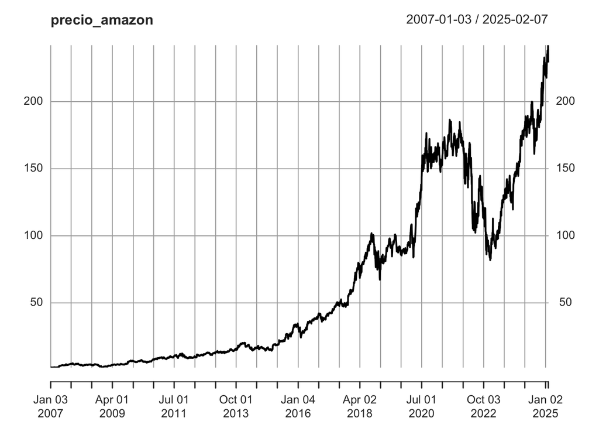

```r
precio_amazon <- datos_amazon[[amazon]][,6]

plot(precio_amazon)
```

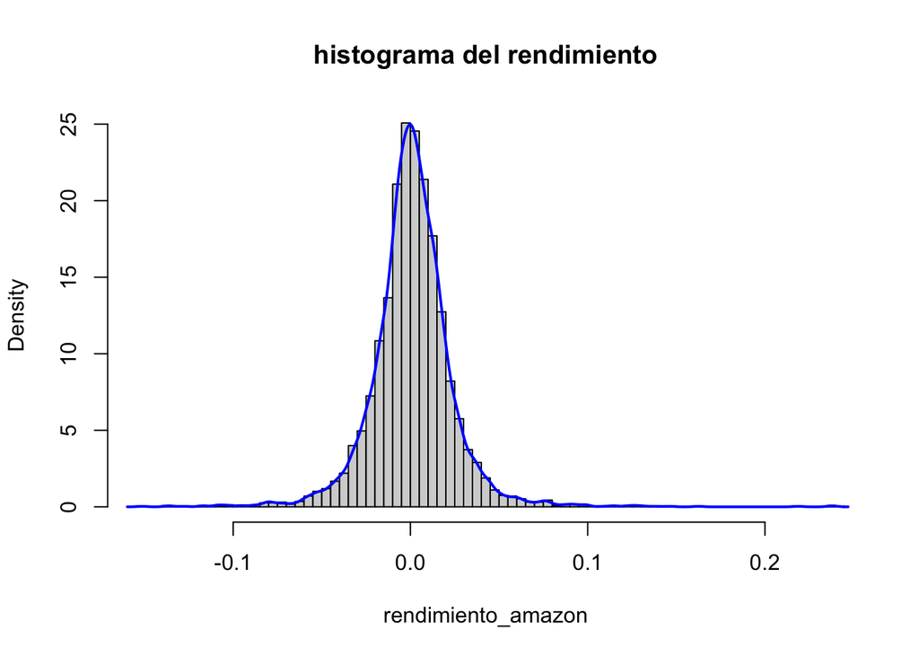

```r
rendimiento_amazon <- na.omit(diff(log(precio_amazon)))
hist(rendimiento_amazon, n = 100,main="histograma del rendimiento", prob = TRUE)
lines(density(rendimiento_amazon), col="blue", lwd=2)
```

```r
xval <- seq(min(rendimiento_amazon),max(rendimiento_amazon), length.out=100)
```

La distribución del rendimiento del precio de amazon tiene una forma acampanada y podemos notar que la media del rendimiento se agrupa alrededor de cero.

## Hecho Estilizado 3

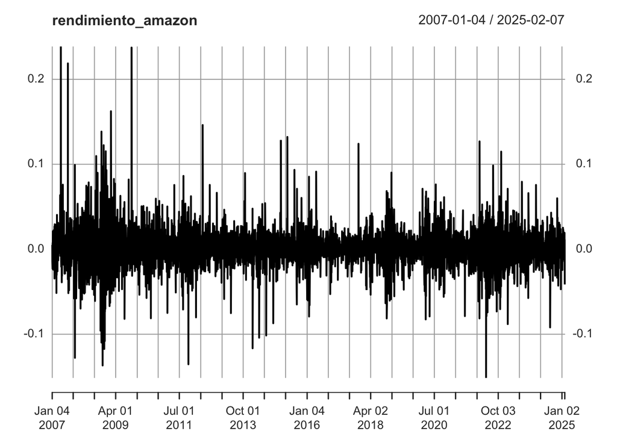

```r
plot(rendimiento_amazon)
```

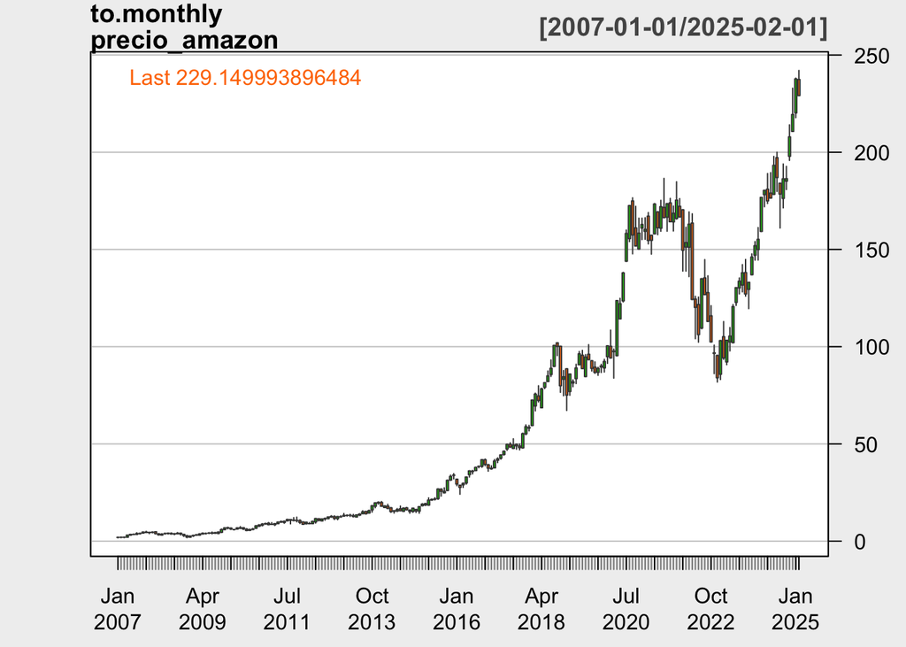

```r
chartSeries(to.monthly(precio_amazon), theme="white")
```

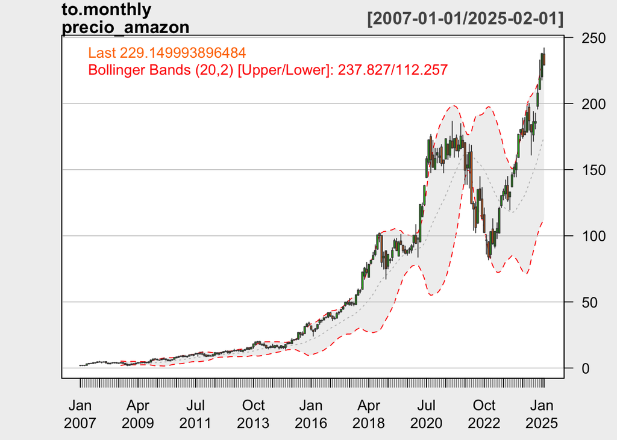

```r
addBBands()
```

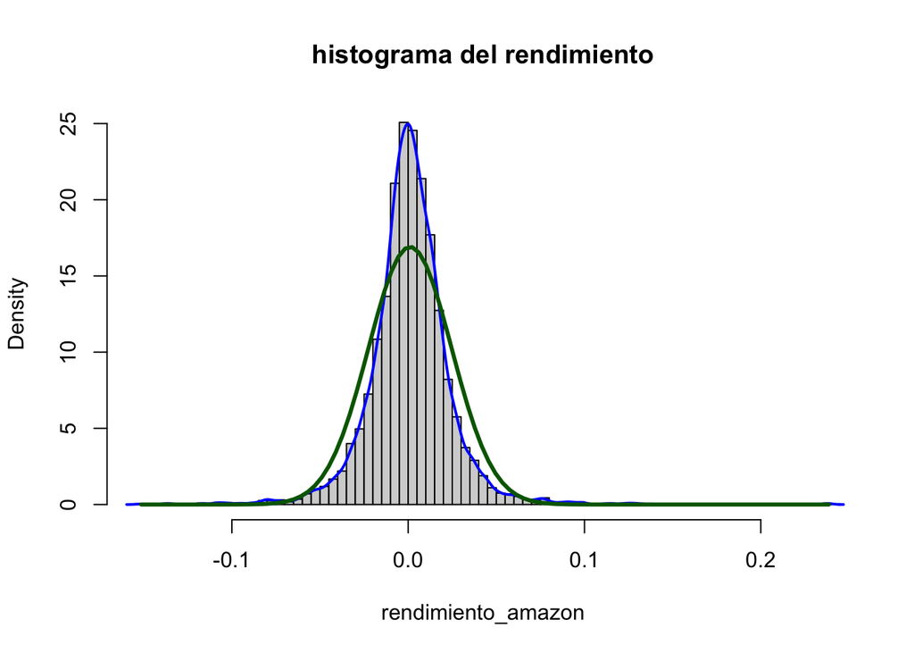

```r
rendimiento_amazon <- na.omit(diff(log(precio_amazon)))
hist(rendimiento_amazon, n = 100,main="histograma del rendimiento", prob = TRUE)
lines(density(rendimiento_amazon), col="blue", lwd=2)
xval <- seq(min(rendimiento_amazon),max(rendimiento_amazon), length.out=100)
lines(xval, dnorm(xval, mean=mean(rendimiento_amazon),sd=sd(rendimiento_amazon)), col="darkgreen",lwd=3)
```

```r
datos_nvidia <- new.env()
nvidia <- "NVDA"
getSymbols(nvidia, env=datos_nvidia)
```

```
## [1] "NVDA"
```

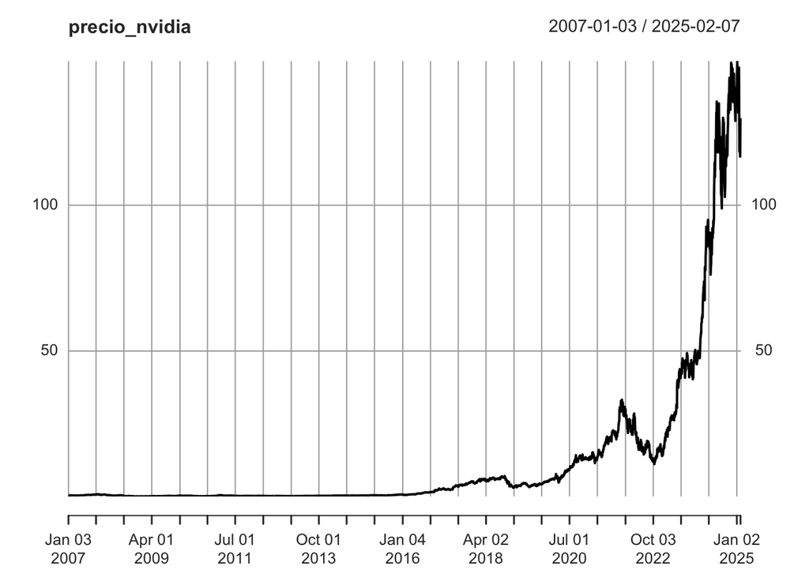

```r
precio_nvidia <- datos_nvidia[[nvidia]][,6]

plot(precio_nvidia)
```

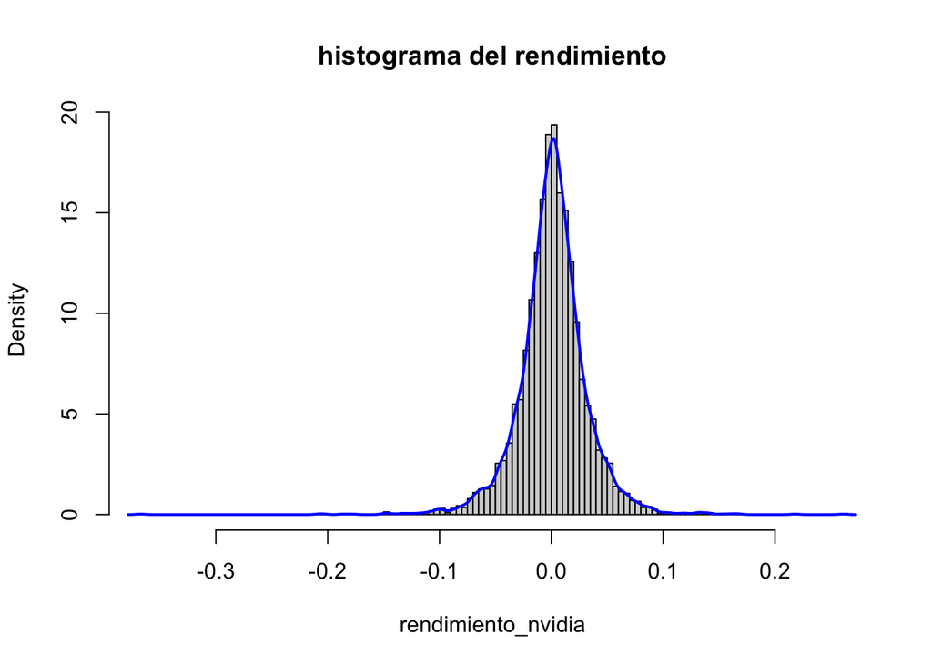

```r
rendimiento_nvidia <- na.omit(diff(log(precio_nvidia)))
hist(rendimiento_nvidia, n = 100,main="histograma del rendimiento", prob = TRUE)
lines(density(rendimiento_nvidia), col="blue", lwd=2)
```

```r
xval <- seq(min(rendimiento_nvidia),max(rendimiento_nvidia), length.out=100)
```

La distribución del rendimiento del precio de nvidia tiene forma aproximadamente acampanada y la media de los rendimientos se agrupan alrededor de cero

## Hecho Estilizado 3

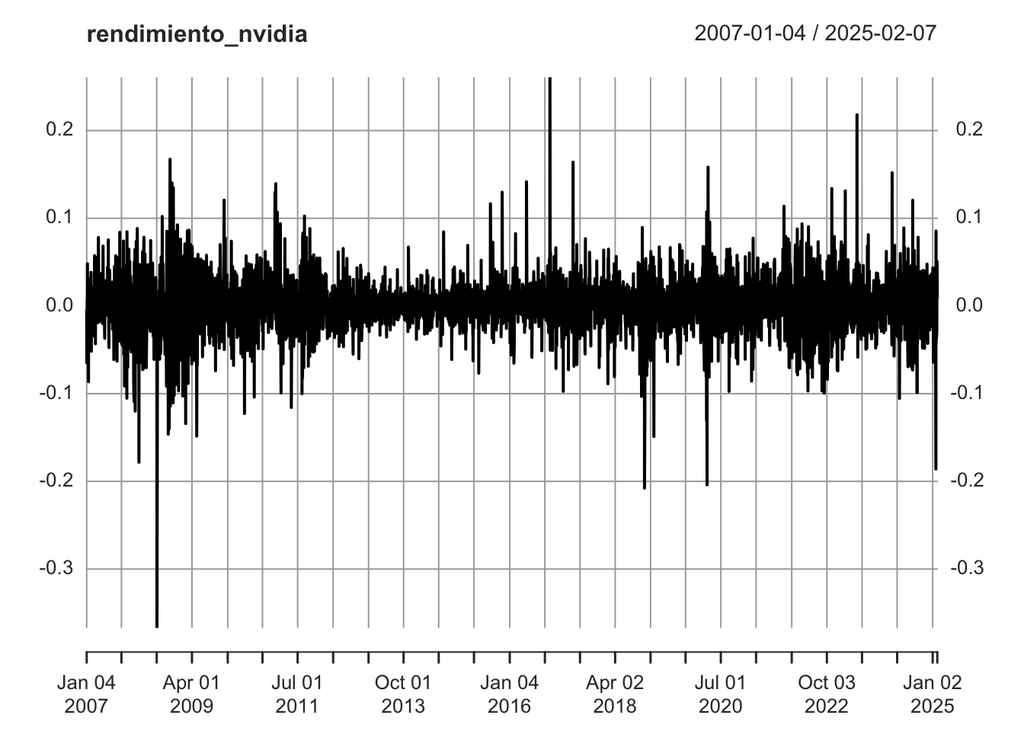

```r
plot(rendimiento_nvidia)
```

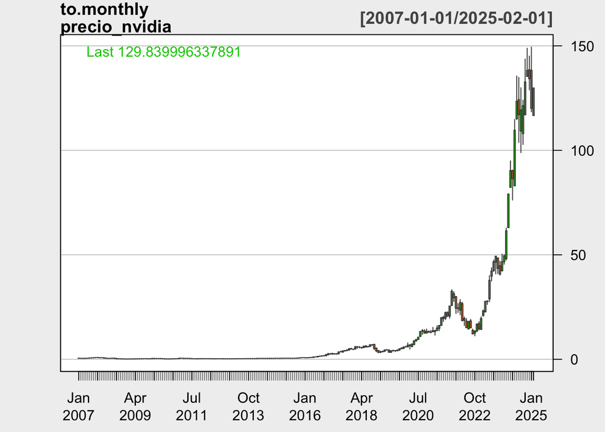

```r
chartSeries(to.monthly(precio_nvidia), theme="white")
```

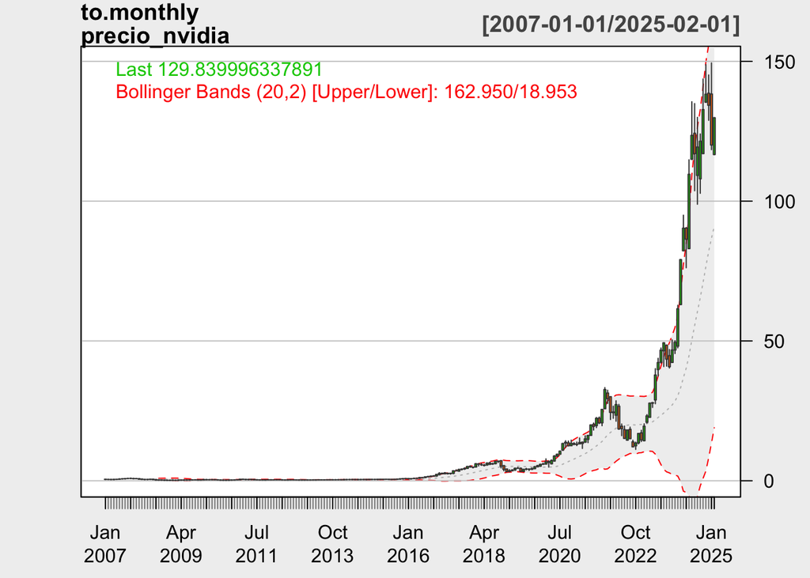

```r
addBBands()
```

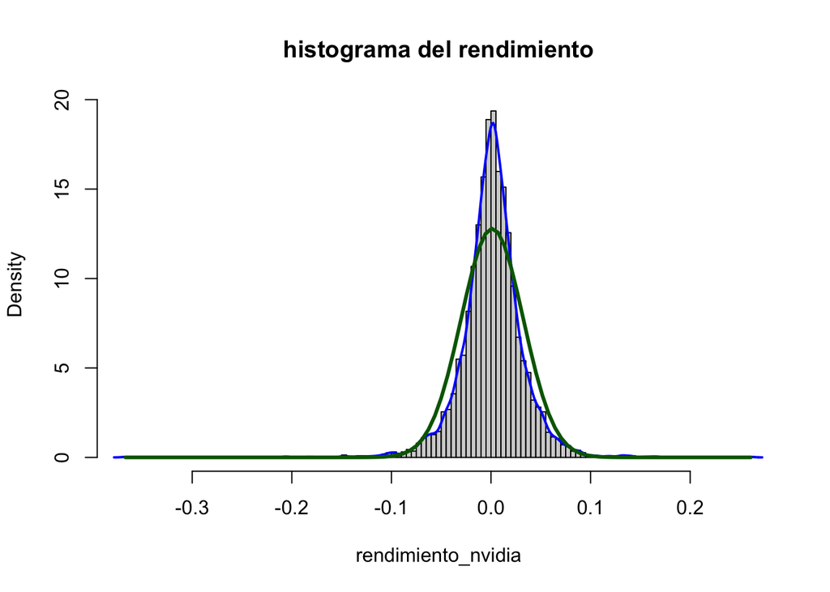

```r
rendimiento_nvidia <- na.omit(diff(log(precio_nvidia)))
hist(rendimiento_nvidia, n = 100,main="histograma del rendimiento", prob = TRUE)
lines(density(rendimiento_nvidia), col="blue", lwd=2)
xval <- seq(min(rendimiento_nvidia),max(rendimiento_nvidia), length.out=100)
lines(xval, dnorm(xval, mean=mean(rendimiento_nvidia),sd=sd(rendimiento_nvidia)), col="darkgreen",lwd=3)
```

La distribución de los rendimientos representa leptocurtosis ya que existe un exceso de datos alrededor de la media.

# Conclusion

En conclusión a pesar de la diferencia de como se mueven los precios de cada activo, los 3 cumplen con los 4 hechos estilizados, los 3 activos tienen un comportamiento similar a una caminata aleatoria, las distribuciones de sus rendimientos son aproximadamentes acampanadas y se agrupan alrededor del cero, los rendimientos de los activos presentan volatilidad no constante y que se tiende a agrupar y la distribución de los rendmientos presentan leptocurtosis.